# 4weeks

zang

2015년 9월 29일

# 과제1

> Mlbench 패키지의 Glass 자료에 대하여 k=2,3…10으로 하여 k-평균 군집법을 적용하고 군집내 오차제곱합과 군집간 오차제곱합의 비를 그려보아라. 오차제곱합의 비에 의해 선택된 최적의 k 값에서의 k 평균 군집결과와 출력변수의 값을 비교하여라. Hcluster로 나온군집결과와 k평균의 군집결과 또한 비교해 보시오

## 데이터셋 가져와서 가공

```r
#install.packages("mlbench")
library(mlbench)
data("Glass")
Glass_lable<-Glass$Type
Glass<-Glass[,-length(Glass)]
Glass<-scale(Glass)
summary(Glass)
```

```
##        RI                Na                Mg                Al
##  Min.   :-2.3759   Min.   :-3.2793   Min.   :-1.8611   Min.   :-2.3132
##  1st Qu.:-0.6068   1st Qu.:-0.6127   1st Qu.:-0.3948   1st Qu.:-0.5106
##  Median :-0.2257   Median :-0.1321   Median : 0.5515   Median :-0.1701
##  Mean   : 0.0000   Mean   : 0.0000   Mean   : 0.0000   Mean   : 0.0000
##  3rd Qu.: 0.2608   3rd Qu.: 0.5108   3rd Qu.: 0.6347   3rd Qu.: 0.3707
##  Max.   : 5.1252   Max.   : 4.8642   Max.   : 1.2517   Max.   : 4.1162
##        Si                K                  Ca                Ba
##  Min.   :-3.6679   Min.   :-0.76213   Min.   :-2.4783   Min.   :-0.3521
##  1st Qu.:-0.4789   1st Qu.:-0.57430   1st Qu.:-0.5038   1st Qu.:-0.3521
##  Median : 0.1795   Median : 0.08884   Median :-0.2508   Median :-0.3521
##  Mean   : 0.0000   Mean   : 0.00000   Mean   : 0.0000   Mean   : 0.0000
##  3rd Qu.: 0.5636   3rd Qu.: 0.17318   3rd Qu.: 0.1515   3rd Qu.:-0.3521
##  Max.   : 3.5622   Max.   : 8.75961   Max.   : 5.0824   Max.   : 5.9832
##        Fe
##  Min.   :-0.5851
##  1st Qu.:-0.5851
##  Median :-0.5851
##  Mean   : 0.0000
##  3rd Qu.: 0.4412
##  Max.   : 4.6490
```

## kmeans 해보기

```r
set.seed(0725)
Glass_kmeans_2<-kmeans(x=Glass,centers =2)
Glass_kmeans_2$totss#총 오차 제곱합
```

```
## [1] 1917
```

```r
Glass_kmeans_2$withinss#군집내 오차제곱합
```

```
## [1]  464.287 1131.970
```

```r
Glass_kmeans_2$betweenss#군집간 오차제곱합
```

```
## [1] 320.7429
```

```r
Glass_kmeans_2$betweenss/Glass_kmeans_2$totss*100#군집간오차제곱합/군집전체 오차제곱합
```

```
## [1] 16.7315
```

```r
Glass_kmeans_2$tot.withinss/Glass_kmeans_2$betweenss#군집내 오차제곱합과 군집간 오차제곱합 비
```

```
## [1] 4.976749
```

> 좋은 클러스터링은 군집간 오차제곱합이 크고 군집내 오차제곱합이 적어야 한다

## kmeans 평가 by 총제곱합분의 군집간오차제곱합

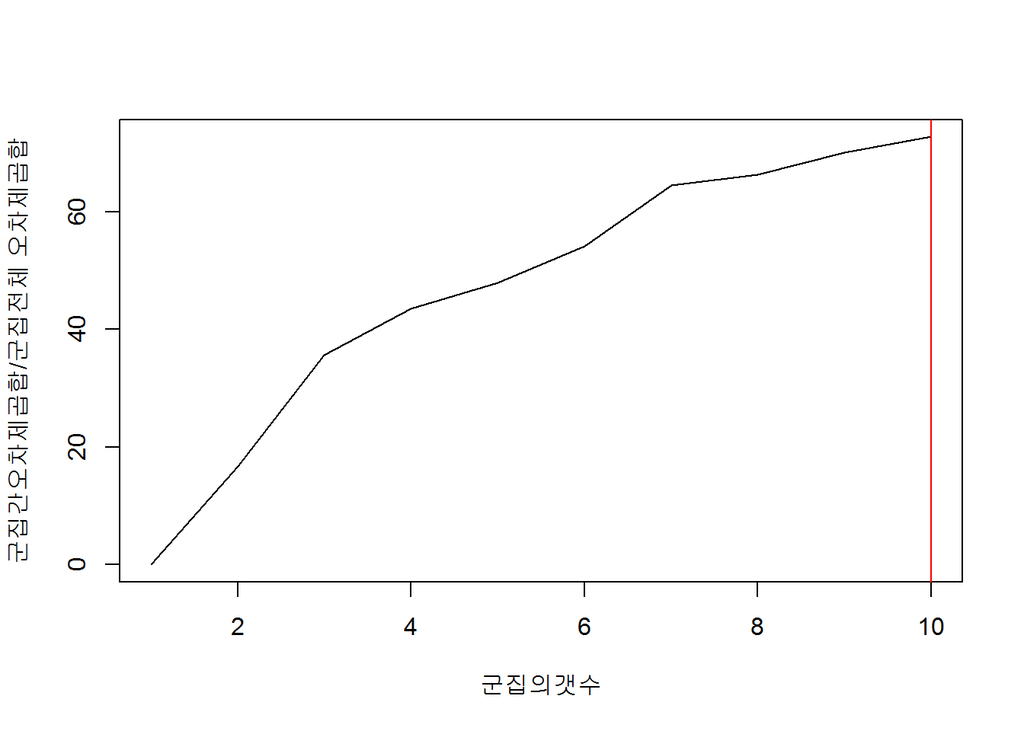

```r
x<-rep(0,10)
for( i in 1:10){
  set.seed(1234)
    Glass_kmeans<-kmeans(x=Glass,centers =i)
  x[i]<-Glass_kmeans$betweenss/Glass_kmeans$totss*100
}

plot(1:10,x,type="l",xlab = "군집의갯수",ylab="군집간오차제곱합/군집전체 오차제곱합")
abline(v=which.max(x),col="red")
```

## kmeans 평가 by 군집내 오차제곱합/군집간오차제곱합

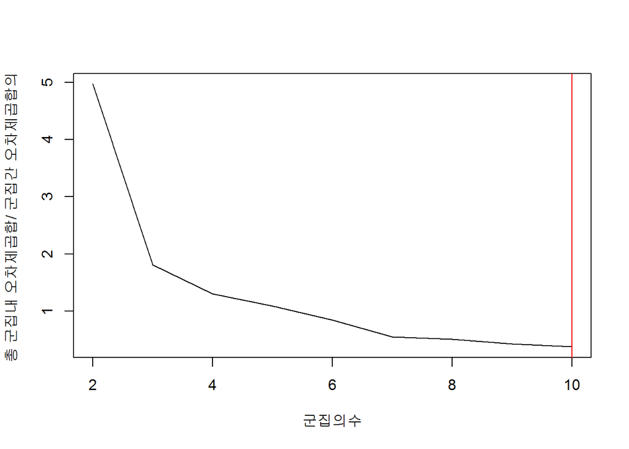

```r
y<-rep(0,9)
for( i in 2:10){
  set.seed(1234)
  Glass_kmeans<-kmeans(x=Glass,centers =i)
  y[i-1]<-Glass_kmeans$tot.withinss/Glass_kmeans$betweenss
}
plot(2:10,y,type="l",xlab = "군집의수",ylab="총 군집내 오차제곱합/ 군집간 오차제곱합의 ")
abline(v=which.min(y)+1,col="red")
```

## kmeans 평가

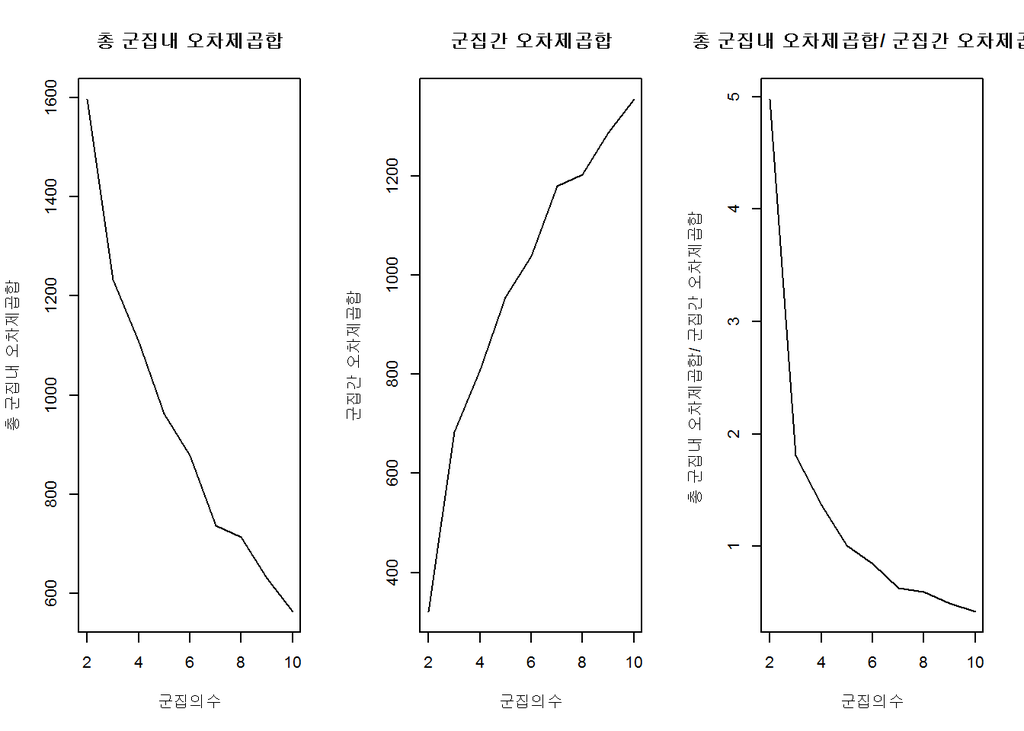

## 원래 type 과 kmwans-cluser 비교

```r
set.seed(0725)
Glass_kmeans_6<-kmeans(x=Glass,centers =6)

par(mfrow=c(1,2))
library(cluster)
```

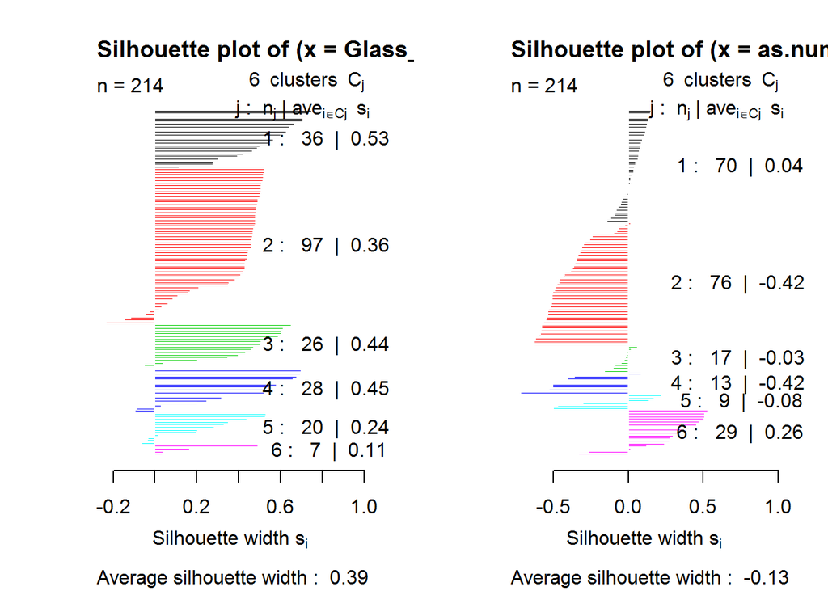

```r
plot(silhouette(Glass_kmeans_6$cluster,dist=dist(Glass)^2),col=1:6)
plot(silhouette(as.numeric(Glass_lable),dist=dist(Glass)^2),col=1:6)
```

## hcluster 와비교

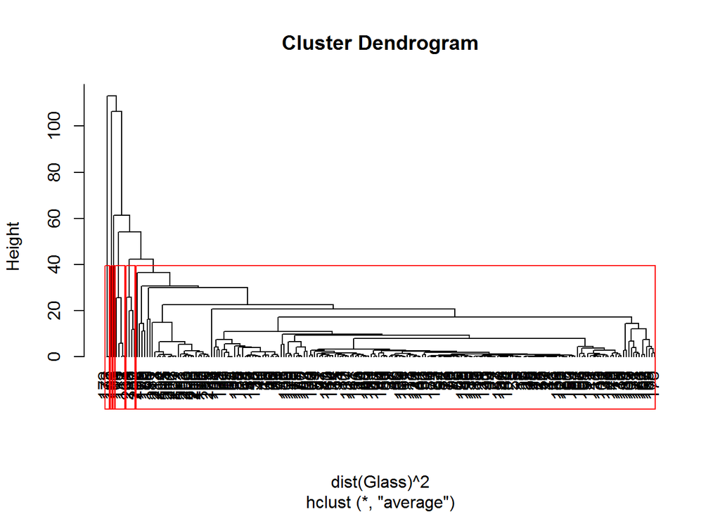

```r
Glass_hmeans<-hclust(d=dist(Glass)^2,method = "average")
plot(Glass_hmeans,hang=-1)
rect.hclust(Glass_hmeans,k=6,border="red")
```

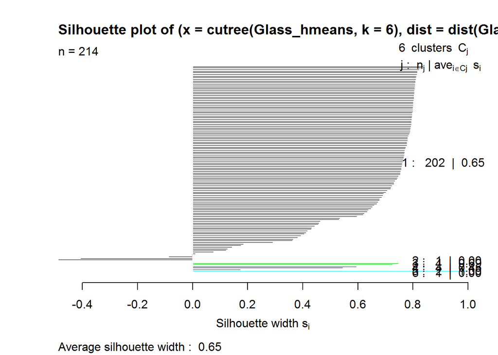

```r
plot(silhouette(cutree(Glass_hmeans,k=6),dist=dist(Glass)^2),col=1:6)
```

```r
result<-NULL
result$real<-Glass_lable
result$kmeans<-as.factor(Glass_kmeans_6$cluster)
result$hmeans<-as.factor(cutree(Glass_hmeans,k=6))
table(result$real,result$kmeans)
```

```
##
##      1  2  3  4  5  6
##   1 12 38  0 20  0  0
##   2 20 42  0  3  4  7
##   3  3 12  0  2  0  0
##   5  1  2  1  0  9  0
##   6  0  1  1  0  7  0
##   7  0  2 24  3  0  0
```

```r
table(result$real,result$hmeans)
```

```
##
##      1  2  3  4  5  6
##   1 70  0  0  0  0  0
##   2 71  1  4  0  0  0
##   3 17  0  0  0  0  0
##   5 10  0  0  1  2  0
##   6  8  0  0  0  0  1
##   7 26  0  0  3  0  0
```

```r
table(result$kmeans,result$hmeans)
```

```
##
##      1  2  3  4  5  6
##   1 36  0  0  0  0  0
##   2 94  0  0  1  2  0
##   3 22  0  0  3  0  1
##   4 28  0  0  0  0  0
##   5 20  0  0  0  0  0
##   6  2  1  4  0  0  0
```

# 과제3

> USArrest data를 가지고(6개로 짤르고) 계층적 분석 돌리고 각 변수들끼리 총 6개의 플랏을 그리고 그 각각의 변수에대한 자기의 생각을 적음 어떠어떠한변수가 영향이있더라 라는것 계층적군집분석 옵션을 k=6로 하라는말 주장하기 힘들다면 k=3으로 바꿔라 6가지 조합의 2차원그래프 urbanpop을 제외한 3차원그래프를 그려와라 어떠한 변수가 6개로 계층 군집하는데 중요하게 쓰였다

## USArrest

```r
data(USArrests)
USArrests_scale<-scale(USArrests)
```

## hcluster

```r
USArrests_hcluser<-hclust(d=dist(USArrests_scale)^2,method = "single")
```

## Hcluster 그림그리기

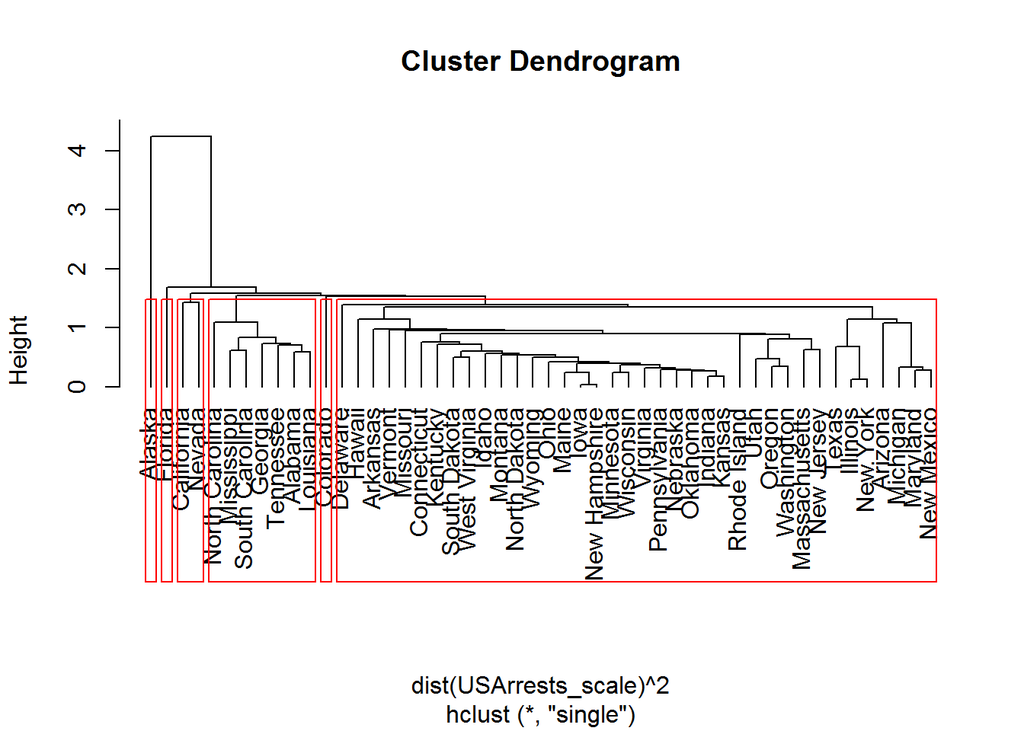

```r
plot(USArrests_hcluser,hang=-1)
rect.hclust(USArrests_hcluser,k=6,border="red")
```

## muder,assult,rape,unbanpop 사이의 관계 보기

```
## [1] "Murder"   "Assault"  "UrbanPop" "Rape"
```

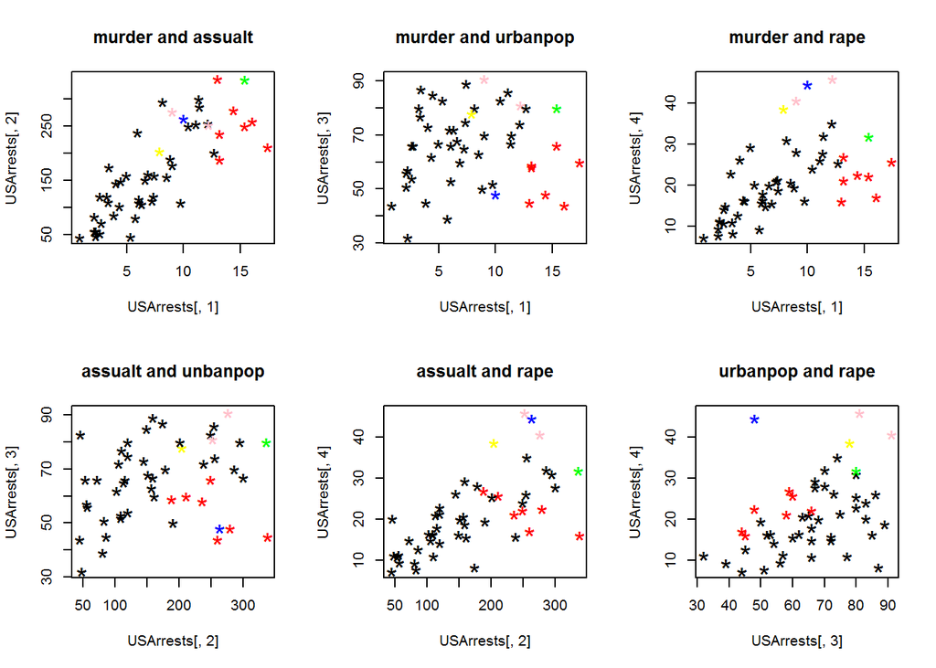

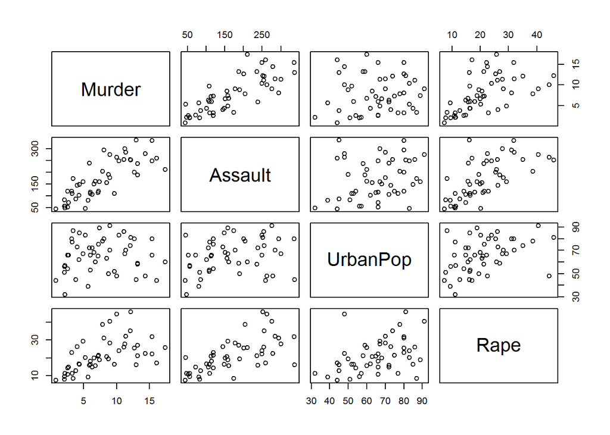

```
##              Murder   Assault   UrbanPop      Rape
## Murder   1.00000000 0.8018733 0.06957262 0.5635788
## Assault  0.80187331 1.0000000 0.25887170 0.6652412
## UrbanPop 0.06957262 0.2588717 1.00000000 0.4113412
## Rape     0.56357883 0.6652412 0.41134124 1.0000000
```

## 변수선택한후에 Hcluster

```r
#변수 3개 선택
USArrests_scale_3variable<-USArrests_scale[,-3]
#클러스터링
USArrests_hcluser_3variable<-hclust(d=dist(USArrests_scale_3variable)^2,method = "single")
USArrests_hcluser_lable_3variable<-cutree(USArrests_hcluser_3variable,k=6)

#install.packages("rgl")
library(rgl)
```

```r
plot3d(USArrests$Murder,USArrests$Assault,USArrests$Rape, col=mypal[USArrests_hcluser_lable_3variable], size=1, type='s', box=T)
#해석 검은점으로 나타낸 클러스터는 전반적인 3가지  특성의 범죄가 모두  낮은곳이고
#빨간점으로 나타나낸 클러스터는 전반적으로 3가지  특성의 범죄가 모두  높은곳이다.
```

[output not shown]